# Using Logistic Regression Models

Matthew Curcio

## Introduction

### Exponential Growth Curves

For individuals who have studied cell biology or biochemistry, logistic regression may be familiar as dose-response curves[^1], enzyme kinetic curves[^2], median lethal dose curve (LD-50)[^3], a four parameters logistic regression, or even an exponential growth curve given limited resources[^4].

The exponential growth curve given limited resources:

$$\begin{equation}
f(x) ~=~ \frac{M}{1 + Ae^{-r(x - x_0)}}
\end{equation}$$

where:

- $M$ is the carrying capacity, the curve’s maximum value
- $r$ is the Malthusian parameter,[^5] or the log growth rate
- $x_0$ is the midpoint of the curve
- $A$ is the number of doublings needed to reach the maximum value[^6]

### Why Use Logistic Regression

Outside of Biology, Logistic Regression is commonly used to assess credit or financial risk, profile customers for churn, and even political polling.

Figure #1 shows an idealized logistic curve.

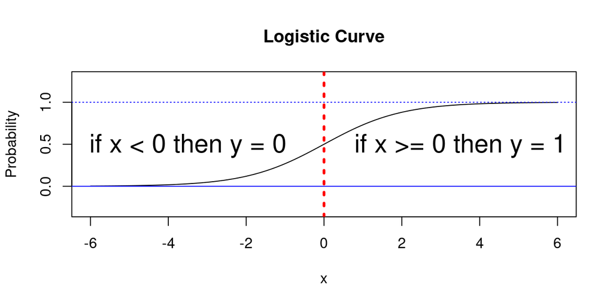

Logistic Regression is used when a decision needs to be analyzed. In particular, when a binary decision needs to made, for example, yes or no, go or no-go.

In our simple case in figure #1, we see that we can take any (integer, fraction or even irrational) number and plug it into our function and will receive numbers between 0 and 1 will be output. The scale on the Y-axis is Probability.

In the same system, we could apply two rules to our new decision making tool. In our graphic we see the sigmoid shaped curve has a midpoint is at $x = 0$. Therefore we *could* set a simple boundary at $x = 0$ and say:

If $x > 0$ then $y = yes$  
Otherwise  
If $x < 0$ then $y = no$

It is easy to see that we could be set our boundary anywhere we choose.

There are other times when a researcher is less concerned with finding {Yes or No}. Instead finding how far along a person is on a spectrum between two states. For example, a bank may have information on income, debt, occupation, education and past loan payment information. The question becomes what is the probability that this person is to pay back a loan.

- The input or predictor variables can be either categorical or continuous.

| Independent Variables | Variable Type |
| --- | --- |
| Income | $/yr, continuous |
| Education, University Degree | yes or no, categorical |

- While the Dependent Variable is categorical.

| Dependent Variable | Variable Type |
| --- | --- |
| Defaulted on loan | yes or no, categorical |

*In the business world*, an investor may want to know how safe is an investment or loan? Using Logistic Regression, a data scientist can determine what criteria is the most important when paying back a loan. If the debt is high then the chances of non-payment become higher.

If one is looking for a finer gradation than {yes, no} then probabilities or odds we may be ideal for Logistic Regression.

### Using Logistic Regression?

Logit is commonly used to determine the relationship between the independent and dependent variables.

Logistic Regression is a supervised machine learning technique. Meaning that the researcher needs to have a label for their data, like an outcome. Knowing whether 10,000 people *payed or defaulted* on their loans is vital for determining the risk for other new loan applicants.

> In psychology circles, it is oft quoted that “the best predictor of future behaviour is past behaviour”. Unfortunately, this is sometimes treated more like a fundamental law of physics than a handy rule of thumb.[^7]

While the output is typically a binary outcome.

It would be more helpful to know the probability (or evens the odds) of receiving its money back.

Logit has several important features. Logit is not only helping us determine the relationship between variables. It helps one understand the importance of each variable to the whole.

For example, Logit does not simply tell the user if the loan should or should not be given. It will provide the probabilities associated with each variable or action. Additionally, if a borrower receives a value of 51%, it may indicate that the loan is given out. But by carefully inspecting the probabilities, we can turn those probabilities into odds. Finding the odds of an occurrence can provide an intuitive understanding of any predictor variables.

The result is the impact of each variable on the odds ratio of the observed event of interest.

Understanding Logit should be studied to understand neural networks better.

In Figure #1, the function’s independent variable(s), may be integers or continuous values. Interestingly, the dependent variable does not provide a 0 or 1 but gives a value between 0 and 1, the probability of that event will occur. In the figure, the *decision boundary* is $x ~=$ 0, denoted by the *red dotted line*. At the mid-point the curves range changes from *zero* (the absence) to *one* (the presence) of a quality or item.

The Logit formula is simplified version of the exponential growth curve. It should be easy to see that the output is (0, 1) inclusive.

The Logistic Regression formula:

$$\begin{equation}
f(x) ~=~ \frac{1}{1 + e^{-(WX+b)}}
\end{equation}$$

where:

- W is the matrix of the features
- b is a constant

Since the logistic equation is exponential, it is easier to work with the formula in terms of its odds, initially *log-odds*.

Odds are (generally) the probability of success over failure denoted as $\Large \frac{p}{1-p}$ and more importantly, in this situation, log-odds are $ln \left (\frac{p}{1-p} \right )$.

$$\begin{equation}
Odds ~=~ \frac{Probability ~of~ Success}{Probability ~of~ Failure}
\end{equation}$$

Simply by using log-odds, logistic regression may be more easily expressed as a set of linear equations in x.[^8] Hence we can now go from linear regression to logistic regression.

$$\begin{equation}
ln \left( \frac {p}{1-p} \right) =~ \beta_1 x_1 + \beta_2 x_2 + ... +
\beta_n x_n
\end{equation}$$

[^1]: https://en.wikipedia.org/wiki/Dose%E2%80%93response_relationship
[^2]: https://www.khanacademy.org/science/ap-biology/cellular-energetics/environmental-impacts-on-enzyme-function/a/basics-of-enzyme-kinetics-graphs
[^3]: https://en.wikipedia.org/wiki/Median_lethal_dose
[^4]: https://openoregon.pressbooks.pub/mhccmajorsbio/chapter/environmental-limits-to-population-growth/
[^5]: https://en.wikipedia.org/wiki/Malthusian_growth_model
[^6]: https://en.wikipedia.org/wiki/Logistic_function
[^7]: https://www.linkedin.com/pulse/best-predictor-future-behaviour-past-except-joshua-wood/
[^8]: http://juangabrielgomila.com/en/logistic-regression-derivation/